# Cours 1: Pourquoi apprendre les méthodes quantitatives?

CRM3734: Méthodes quantitatives en criminologie

Jean-Denis David, Ph.D.

2026

## Pourquoi apprendre les méthodes quantitatives?

Les criminologues pose des questions importantes pour lesquels les réponses relèvent fréquement de données de nature numérique et catégorielle.

- *Les peines plus sévères réduisent-elles vraiment la criminalité?*
- *La surreprésentation des autochtones dans les milieux carcéraux a-t-elle augmentées depuis 1990?*
- *En quelle mesures les quartiers défavorisés sont-ils assujeti à une présence policières accrue comparativement aux quartiers mieux nanties?*

**Élément important**

Les méthodes quantantitatives ne sont pas seulement un ensemble de calculs. C’est d’abord **une approche systématique pour raisonner avec des données numériques et catégorielles** souvent imparfaites.

## Deux regards sur un même phénomène

Les méthodes quantitatives et qualitatives ne s’opposent pas. Elles répondent à des questions différentes et deviennent bien souvent complémentaires.

#### Approche qualitative

- Cherche le sens, le contexte, l’expérience.
- S’appuie sur des entretiens, observations, récits, dossiers.
- Aide à comprendre le **comment** et le **pourquoi**.

#### Approche quantitative

- Cherche les régularités, les écarts, les tendances.
- S’appuie sur des données numériques et catégorielles.
- Aide à comprendre le **combien**, **à quelle fréquence**, **pour qui.**

## Les méthodes quantitatives et les statistiques

Les **méthodes quantitatives** représentent l’approche globale de recherche basée sur des données numériques et catégorielles.

Les **statistiques** forment l’ensemble des techniques utilisés pour analyser ces données.

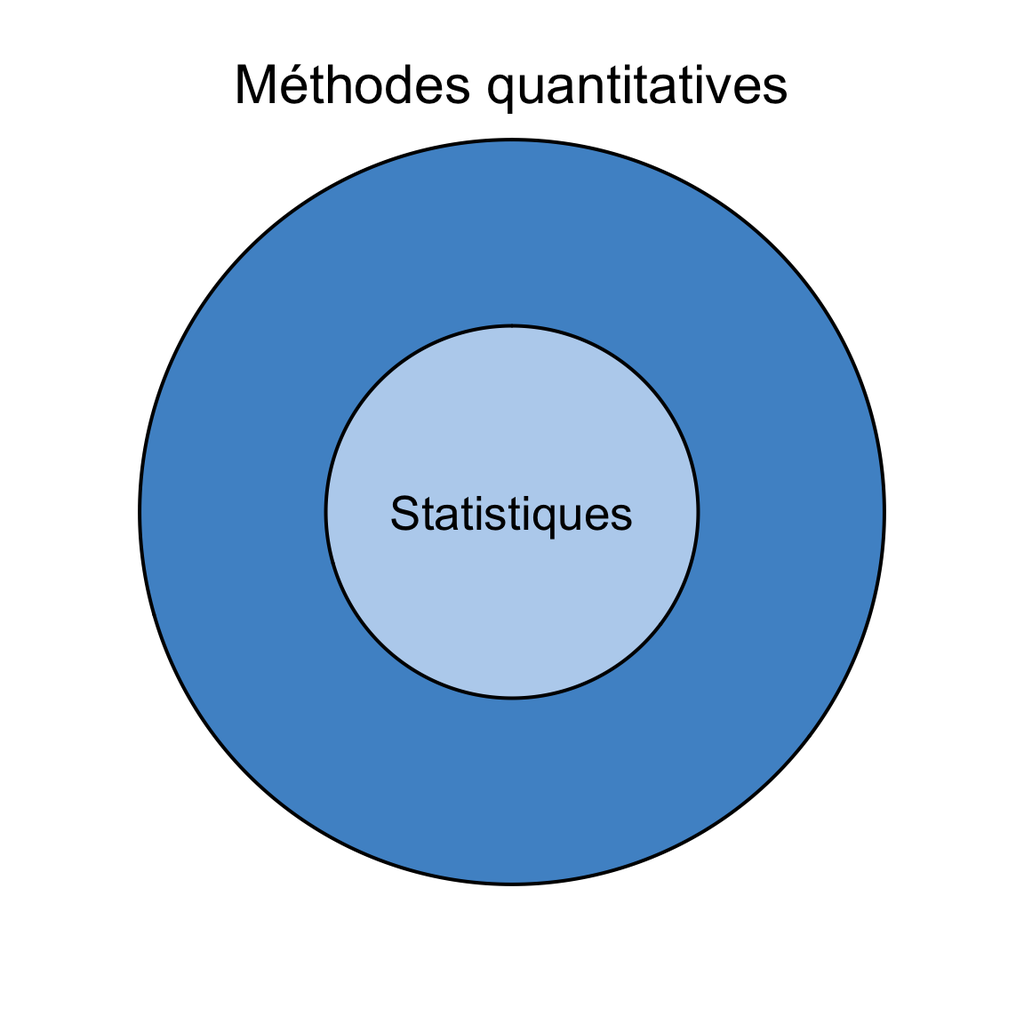

## Définitions

**Méthodes quantitatives**

Ensemble de méthodes permettant de **résumer**, **comparer**, **interpréter** et **visualiser** des données numériques et catégorielles, tout en indiquant **le degré d’incertitude** qui accompagne ces résultats.

**Données numériques**

Les données numériques sont des informations exprimées sous forme de nombres.

*Il y a plus de 200 services de police au Canada.*

**Données catégorielle**

Les données catégorielles sont des informations classées en catégories ou groupes.

*Les victimes, les accusés et les témoins.*

## D’où viennent les données criminologiques?

Les données du cours ressembleront à celles utilisées dans la pratique :

**Statistiques policières** Infractions portées à l’attention de la police.

**Enquêtes de victimisation** Expériences déclarées par les personnes.

**Données correctionnelles** Admissions, séjours, libérations.

**Données judiciaires** Accusations, verdicts, peines.

**Données socioéconomiques** Pauvreté, âge, quartier, scolarité.

## Données incomplètes

Collecter des données sur des phénomènes sociales est un défi.

- Utilisation d’échantillon.
- Niveau de précision variable.
- Non-réponses et réponses inexacte.
- Outil de collecte non-standard.

Ainsi, les données sociales sont rarement complètes.

**Important**

Le premier réflexe d’un bon analyste n’est pas seulement de se demander “que disent les chiffres?” mais aussi “quelles sont leurs limites?”

## Données incomplètes: le chiffre noir de la criminalité

Certaines formes de victimisation ou d’infraction restent partiellement invisibles dans les statistiques officielles.

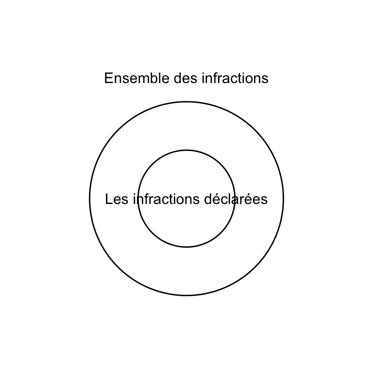

Plus le phénomène est sensible, stigmatisé, privé ou difficile à déclarer, plus l’écart entre le cercle extérieur et le centre peut être grand.

## Le fil conducteur de la session

Pendant tout le semestre, nous reviendrons à une même question :

Que peut-on apprendre sur le crime, les institutions et les inégalités à partir de données toujours incomplètes?

`1.` comprendre ce que font les statistiques

`2.` voir pourquoi elles sont indispensables en criminologie

`3.` établir les grandes idées du cours sans vous noyer dans la technique

## La statistique, en une phrase

**Statistique**

Ensemble de méthodes permettant de **résumer**, **comparer** et **interpréter** des données, tout en indiquant **le degré d’incertitude** qui accompagne ces résultats.

**Elle rend les données lisibles**

- tendances
- écarts
- comparaisons

**Elle rend le doute visible**

- hasard
- fragilité
- précision

## Pourquoi la statistique est centrale en criminologie

**Sans statistique**

- beaucoup d’intuitions
- quelques cas frappants
- des débats publics souvent trop rapides
- peu de moyens de vérifier

**Avec statistique**

- tendances plutôt qu’anecdotes
- comparaisons explicites
- évaluation de politiques
- mesure de l’incertitude

## Deux regards sur un même phénomène

### Approche qualitative

- cherche le sens, le contexte, l’expérience
- s’appuie sur des entretiens, observations, récits, dossiers
- aide à comprendre **comment** et **pourquoi**

### Approche quantitative

- cherche des régularités, écarts, tendances
- s’appuie sur des variables, comptages, comparaisons, modèles
- aide à comprendre **combien**, **à quelle fréquence**, **pour qui**

En criminologie, ces approches ne s’opposent pas. Elles répondent à des questions différentes et deviennent souvent plus fortes lorsqu’elles se complètent.

# Les données

## Les données

Étape 1 du raisonnement

Que comptons-nous exactement?

Avant toute analyse, il faut savoir d’où viennent les chiffres et ce qu’ils laissent hors champ.

## D’où viennent les données criminologiques?

Les données du cours ressembleront à celles utilisées dans la pratique :

**Statistiques policières** Infractions portées à l’attention de la police.

**Enquêtes de victimisation** Expériences déclarées par les personnes.

**Données correctionnelles** Admissions, séjours, libérations.

**Données judiciaires** Accusations, verdicts, peines.

**Données socioéconomiques** Pauvreté, âge, quartier, scolarité.

## Une première mise en garde

Les données criminelles ne mesurent jamais “la criminalité” au complet.

Elles mesurent plutôt :

- des événements enregistrés
- des comportements déclarés
- des décisions institutionnelles
- des catégories administratives

**Important**

Le premier réflexe d’un bon analyste n’est pas seulement “Que disent les chiffres?” mais aussi “Que comptent-ils exactement?”

## Le chiffre noir de la criminalité

Certaines formes de victimisation ou d’infraction restent partiellement invisibles dans les statistiques officielles.

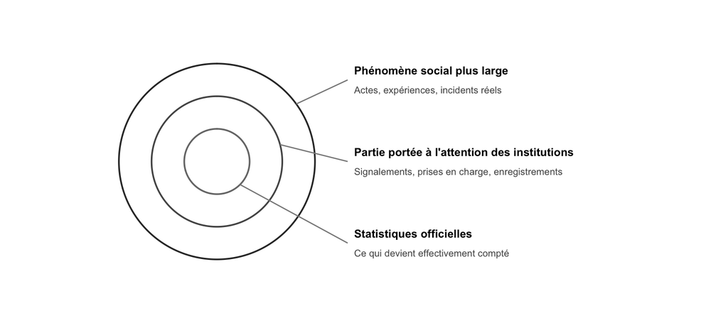

Plus le phénomène est sensible, stigmatisé, privé ou difficile à déclarer, plus l’écart entre le cercle extérieur et le centre peut être grand.

# Des questions aux résultats

## Des questions aux résultats

Étape 2 du raisonnement

Comment une intuition devient-elle une analyse?

Le travail statistique est un enchaînement de décisions, pas une formule magique.

## Une analyse quantitative suit un processus

**1. Formuler**

Transformer une intuition en question précise.

**2. Mesurer**

Choisir les variables et recueillir les données.

**3. Examiner**

Nettoyer, décrire, comparer, visualiser.

**4. Interpréter**

Relier les résultats à une théorie et à leurs limites.

## Exemple simple

Les quartiers plus défavorisés enregistrent-ils davantage d’infractions contre les biens?

Pour y répondre, il faut au minimum :

- définir ce qu’on entend par “défavorisé”
- définir ce qu’on entend par “criminalité”
- choisir l’unité d’analyse : individu, rue, secteur, ville
- comparer sans confondre corrélation et causalité

# Décrire et inférer

## Décrire et inférer

Étape 3 du raisonnement

Voir ce qu’on observe, puis juger ce que cela permet de conclure

La description organise les données. L’inférence évalue jusqu’où on peut généraliser.

## Deux usages complémentaires des statistiques

### Statistiques descriptives

Elles répondent à la question :

**Que voit-on dans les données?**

- moyennes
- proportions
- tableaux
- graphiques

### Statistiques inférentielles

Elles répondent à la question :

**Que peut-on conclure au-delà des données observées?**

- généralisation
- incertitude
- hasard
- précision

## Pourquoi décrire ne suffit pas toujours

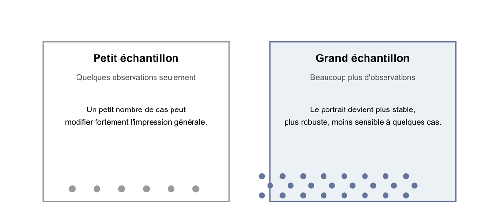

L’idée du jour n’est pas la formule. C’est l’intuition suivante : un résultat fondé sur très peu d’observations est plus fragile.

# Population et échantillon

## Population et échantillon

Étape 4 du raisonnement

Ce que nous observons n’est presque jamais le tout

L’inférence commence avec cette asymétrie simple : peu de cas observés, beaucoup de conclusions tentantes.

## L’idée clé

Nous observons rarement toute la population qui nous intéresse.

Le plus souvent, nous travaillons avec un **échantillon**, puis nous essayons de dire quelque chose de défendable sur une **population**.

## Voir la différence

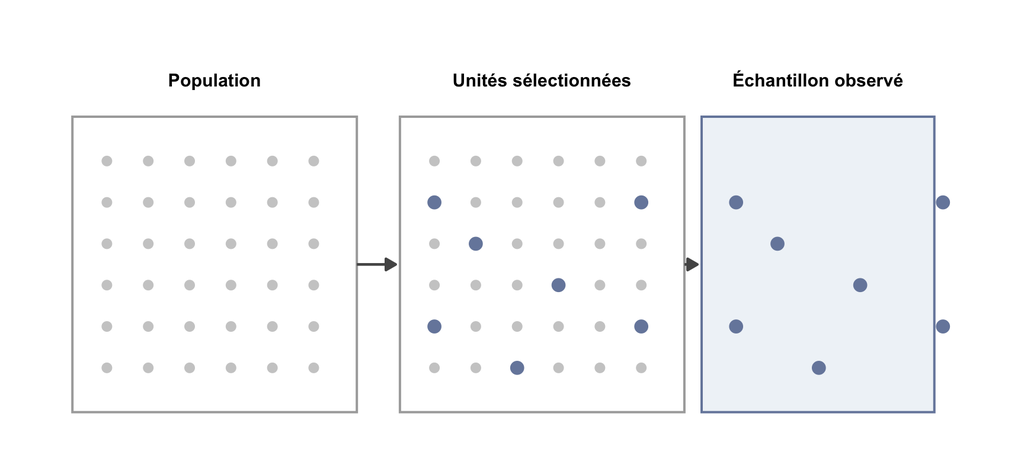

Dans le cours, une grande partie du raisonnement statistique consiste à ne pas oublier ce passage de l’échantillon vers la population.

## Ce que l’inférence essaie de faire

L’objectif central de l’inférence statistique est de déterminer si un résultat observé dans un échantillon :

- reflète vraisemblablement un phénomène plus général
- ou pourrait être compatible avec le hasard et l’imprécision

# Corrélation et causalité

## Corrélation et causalité

Étape 5 du raisonnement

Pourquoi une association n’est pas encore une explication

Le lien observé entre deux variables peut être réel, trompeur ou partiel. Il faut apprendre à résister au raccourci causal.

## Une des erreurs les plus fréquentes

Quand deux variables évoluent ensemble, il est tentant de conclure qu’une cause l’autre.

En criminologie, cette erreur est coûteuse :

- elle produit de mauvaises explications
- elle encourage des politiques mal ciblées
- elle transforme parfois une association brute en slogan causal

## Exemple classique

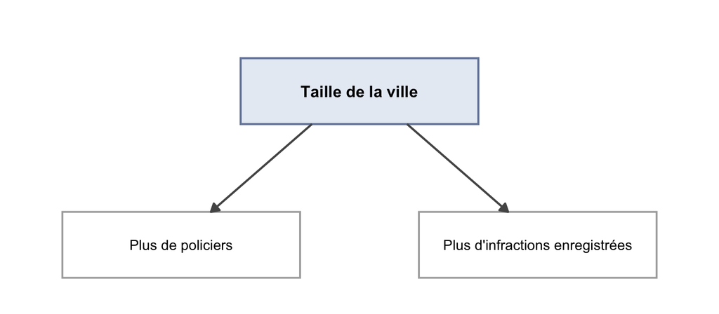

Deux phénomènes peuvent évoluer ensemble sans que l’un soit la cause directe de l’autre.

## Ce que montre vraiment ce schéma

Il peut être vrai que :

- les grandes villes ont plus de policiers
- les grandes villes enregistrent aussi plus d’infractions

Le lien observé entre police et criminalité peut donc être **associé à une troisième variable**, plutôt qu’à un effet causal direct.

# Ce que vous apprendrez

## Ce que vous apprendrez

Ce que ce cours entraîne

Une discipline de lecture, de jugement et d’interprétation

Le but n’est pas d’impressionner avec du vocabulaire technique, mais de raisonner plus proprement.

## Les compétences du cours

À la fin de la session, vous devriez être capables de :

- lire un article quantitatif sans vous laisser impressionner par le vocabulaire
- produire plus tard des tableaux et des graphiques clairs
- interpréter des résultats avec prudence
- reconnaître les limites d’une base de données
- distinguer description, inférence et causalité

## Ce que le cours ne vous demande pas

Vous n’avez pas besoin :

- d’aimer les calculs pour eux-mêmes
- d’être “fort en maths” au sens scolaire du terme
- de mémoriser des formules sans comprendre leur utilité

Votre travail intellectuel consistera surtout à **poser de bonnes questions** et à **interpréter avec rigueur** ce que les données permettent, et ne permettent pas, d’affirmer.

# Les outils

## Les outils

Méthode de travail

Pourquoi le cours passera par du code

Parce qu’une analyse convaincante doit aussi être vérifiable et reproductible.

## Pourquoi nous utiliserons R

R est un langage de programmation conçu pour travailler avec des données.

Nous l’utiliserons parce qu’il est :

- gratuit
- puissant
- largement employé en recherche
- reproductible, donc plus rigoureux qu’un travail fait à la main

## La logique de la reproductibilité

Une analyse reproductible laisse une trace explicite :

- des données utilisées
- des transformations effectuées
- des figures produites
- des choix analytiques

L’objectif n’est pas seulement d’obtenir un résultat.

L’objectif est de pouvoir montrer **comment** ce résultat a été produit.

# Conclusion

## Conclusion

Idée directrice

Les statistiques servent moins à certifier qu’à mieux questionner

Le cours commence ici : apprendre à transformer des chiffres en arguments discutables, plutôt qu’en slogans.

## L’idée à retenir après ce premier cours

La statistique est moins une machine à produire des certitudes qu’un ensemble d’outils pour **réduire l’arbitraire** dans notre manière de raisonner sur le monde social.

En criminologie, elle est utile parce qu’elle nous aide à passer :

- d’impressions à des comparaisons
- d’anecdotes à des tendances
- d’arguments rhétoriques à des preuves discutables, mais explicites

## Pour la suite

Au prochain cours, nous commencerons à travailler plus concrètement avec les données :

- types de variables
- niveaux de mesure
- premières descriptions numériques et graphiques

Le cours ne vous demande pas de croire aveuglément aux chiffres. Il vous demande d’apprendre à mieux les interroger.